# Univariate Analysis

Harsha Achyuthuni

November 30, 2018

## Introduction

Uni-variate analysis is the simplest form of EDA. “Uni” means “one”, so in other words your data has only one variable.

It doesn’t deal with causes or relationships and it’s major purpose is to describe; it takes data, summarizes that data and finds patterns in the data.

In describing or characterizing the observations of an individual variable, there are three basic properties that are of interest:

1. The location of observations, or how large or small the values of the individual observations are
2. The dispersion (sometimes called scale or spread) of the observations
3. The distribution of the observations

Uni-variate plots provide one way to find out about those properties. There are two basic kinds of uni variate plots:

1. Enumeration plots, or plots that show every observation
2. Summary plots, that generalize the data into a simplified representation.

For the current tutorial, I will be using my office attendance data set. The data set contains the time when I swiped into office and the time when I swiped out of office. Data from 4th October 2017 to 29th November 2018.

After some manipulation on the data set, I will get the difference between policy in-time and my actual in-time. 15 minutes after the policy in-time is accepted, but after that I will have to apply for a half day. A sample of the data after manipulation is as follows:

```
##     Attendance.Date diff.in.time diff.out.time
## 109      2018-06-18     -11 mins       63 mins
## 38       2018-10-01      -9 mins       46 mins
## 128      2018-05-17       8 mins       -9 mins
## 260      2017-11-03     122 mins       33 mins
## 179      2018-03-02       7 mins       -8 mins
```

## Summary Statistics

Some basic summary statistics before further analysis would me the basic mean and standard deviation of the data. For this tutorial, I will use diff.in.time (difference between actual in-time and policy in-time)

```r
mean(as.numeric(attendance$diff.in.time)) # Mean in minutes
```

```
## [1] 16.94306
```

```r
sd(as.numeric(attendance$diff.in.time)) # Standard Deviation in minutes
```

```
## [1] 48.65546
```

```r
nrow(attendance) # Length of the data set
```

```
## [1] 281
```

## Enumerative plots

“Enumerative plots” are called such because they enumerate or show every individual data point

### Index Plot/Univariate Scatter Diagram

Displays the values of a single variable for each observation using symbols, with values of the variable for each observation plotted relative to the observation number

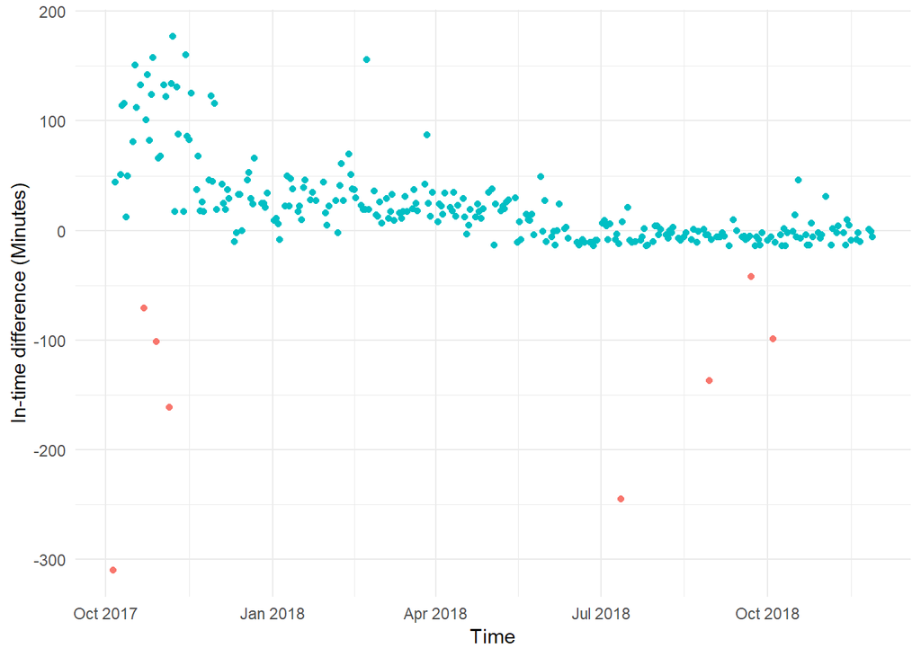

```r
ggplot(attendance, aes(x=Attendance.Date, y= as.numeric(diff.in.time), color = (diff.in.time >= -15))) +
  geom_point(show.legend = FALSE) +
  labs(x = 'Time', y='In-time difference (Minutes)') +
  theme_minimal()
```

Just looking at this plot I can say the following:

1. I could cluster into three parts, One cluster would be before December 2017, where I used to go to office way before my in-time, second cluster would be from December 2017 to June 2018, where I used to go to office somewhat before in-time, and after June 2018, when I am going within 15 minutes after my in-time.
2. The red dots indicate the days when I came to office after 15 minutes from in-time. They are anomalies, days when I took half days etc.. We can exclude them from our current analysis.

### Y Zero High-Density Plot

Another way to look at the same data is by using a Y Zero High-Density Plot. It displays the values of a single variable plotted as thin vertical lines. Here the magnitude of the observations are highlighted.

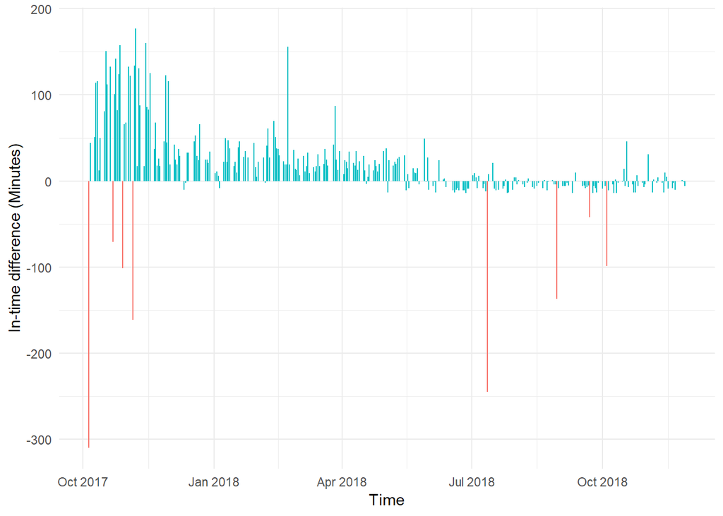

```r
ggplot(attendance, aes(x=Attendance.Date, y = 0, color = (diff.in.time >= -15),
                       xend = Attendance.Date, yend = as.numeric(diff.in.time))) +
  geom_segment(show.legend = FALSE) +
  labs(x = 'Time', y='In-time difference (Minutes)') +
  theme_minimal()
```

Removing half-days as outliers

```r
attendance <- attendance %>%
  filter(diff.in.time >= -15)
```

### Strip Plot/Strip Chart (univariate scatter diagram)

Displays the values of a single variable as symbols plotted along a line. This is a basic plot where we can see the spread of the data.

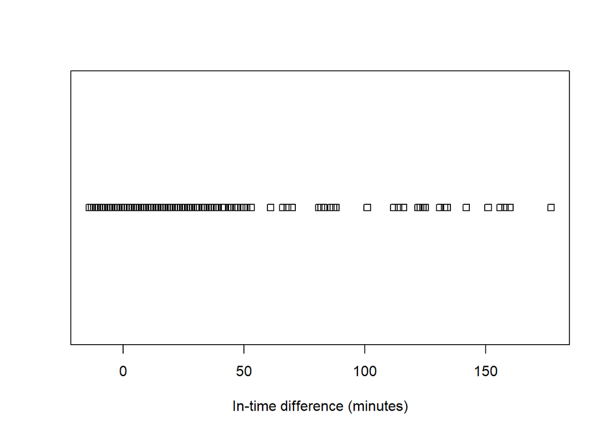

```r
stripchart(x = as.numeric(attendance$diff.in.time),xlab = 'In-time difference (minutes)')
```

Sometimes it is more visually apparent when the points are stacked.

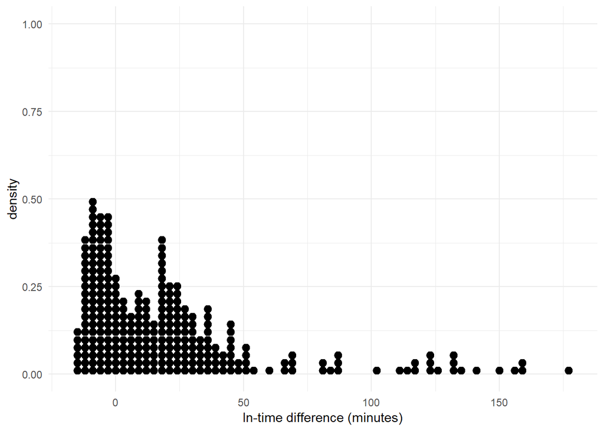

```r
ggplot(attendance, aes(x = as.numeric(diff.in.time), y=..density..))+
  geom_dotplot(binwidth = 3,method = 'histodot') +
  labs(x = 'In-time difference (minutes)') +
  theme_minimal()
```

### Dot Plot/Dot Chart

Displays the values of a single variable as symbols plotted along a line. With a separate line for each observation, it is generally constructed after sorting the rows of the data table.

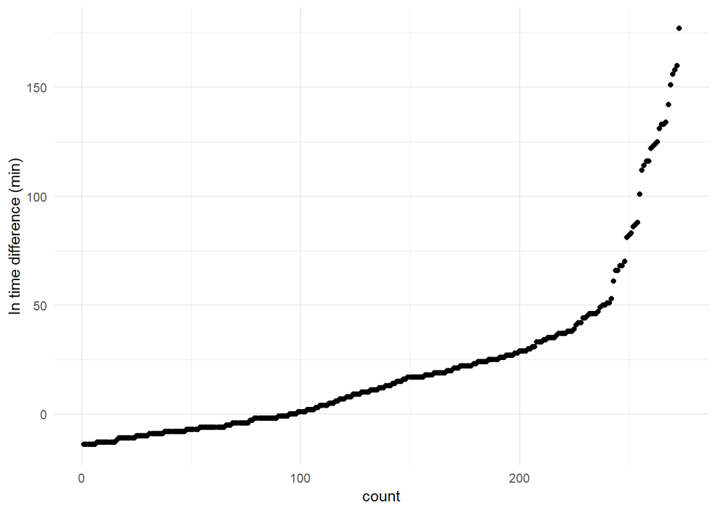

```r
df = attendance %>% arrange(as.numeric(diff.in.time))
ggplot(df,
       aes(x=as.numeric(row.names(df)), y = as.numeric(diff.in.time))) +
  geom_point() +
  labs(x = 'count', y='In time difference (min)') +
  theme_minimal()
```

From the graph I can observe that the distribution initially seems to be a exponential distribution.  
A sample normal distribution is plotted for reference.

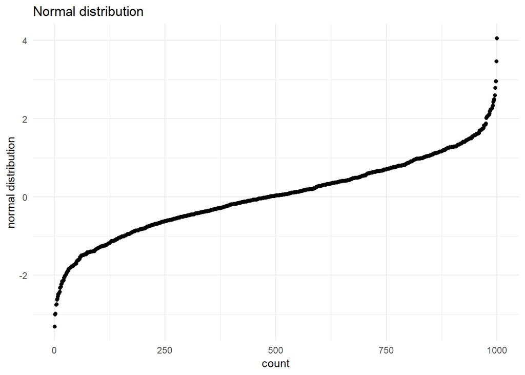

We can see that the distribution looks no where like a normal distribution. I suspect that it is close to a exponential distribution.

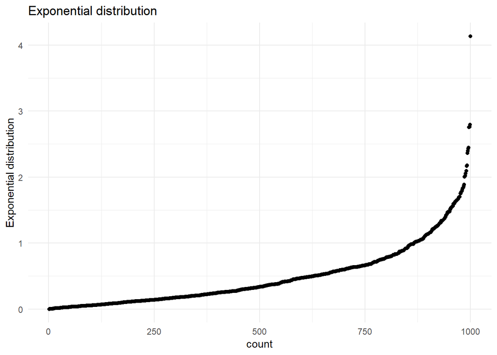

## Univariate Summary Plots

Summary plots display an object or a graph that gives a more concise expression of the location, dispersion, and distribution of a variable than an enumerative plot, but this comes at the expense of some loss of information: In a summary plot, it is no longer possible to retrieve the individual data value, but this loss is usually matched by the gain in understanding that results from the efficient representation of the data. Summary plots generally prove to be much better than the enumerative plots in revealing the distribution of the data.

### Box plot

A simple way of representing statistical data on a plot in which a rectangle is drawn to represent the second and third quartiles, usually with a vertical line inside to indicate the median value. The lower and upper quartiles are shown as horizontal lines either side of the rectangle.

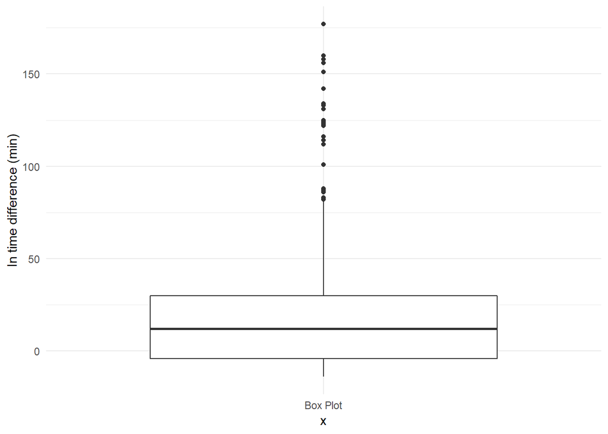

```r
ggplot(attendance, aes(x="Box Plot", y= as.numeric(diff.in.time), group = 123)) +
  geom_boxplot() +
  labs(y='In time difference (min)') +
  theme_minimal()
```

### Histograms

The other summary plots are of various types:

1. Histograms: Histograms are a type of bar chart that displays the counts or relative frequencies of values falling in different class intervals or ranges.
2. Density Plots: A density plot is a plot of the local relative frequency or density of points along the number line or x-axis of a plot. The local density is determined by summing the individual “kernel” densities for each point. Where points occur more frequently, this sum, and consequently the local density, will be greater.

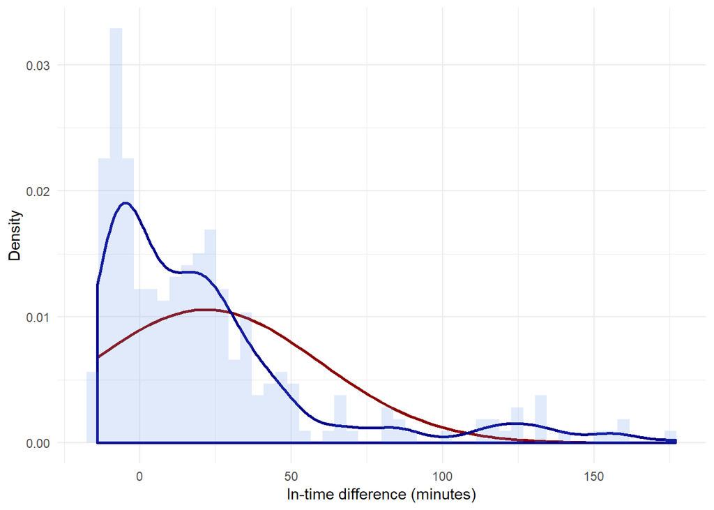

```r
ggplot(attendance,aes(x = as.numeric(diff.in.time))) +
  stat_function(fun = dnorm, color="darkred",  size = 1,
                args = list(mean = mean(as.numeric(attendance$diff.in.time)),
                                         sd = sd(as.numeric(attendance$diff.in.time)) )) +
  geom_density(aes(y=..density..), color="darkblue",  size = 1)+
  geom_histogram(aes(y=..density..), bins = 50, fill = "cornflowerblue", alpha = 0.2) +
  labs(x = 'In-time difference (minutes)', y='Density') +
  theme_minimal()
```

In the above graph, the red line is normal distribution(with the same mean and sd) while the blue line is the density plot of in-time.

### Q-Q plot

In statistics, a Q-Q (quantile-quantile) plot is a probability plot, which is a graphical method for comparing two probability distributions by plotting their quantiles against each other.

If the two distributions being compared are similar, the points in the Q-Q plot will approximately lie on the line y = x. If the distributions are linearly related, the points in the Q-Q plot will approximately lie on a line, but not necessarily on the line y = x. Q-Q plots can also be used as a graphical means of estimating parameters in a location-scale family of distributions.

A Q-Q plot is used to compare the shapes of distributions, providing a graphical view of how properties such as location, scale, and skewness are similar or different in the two distributions.

Below is a Q-Q plot with a normal distribution

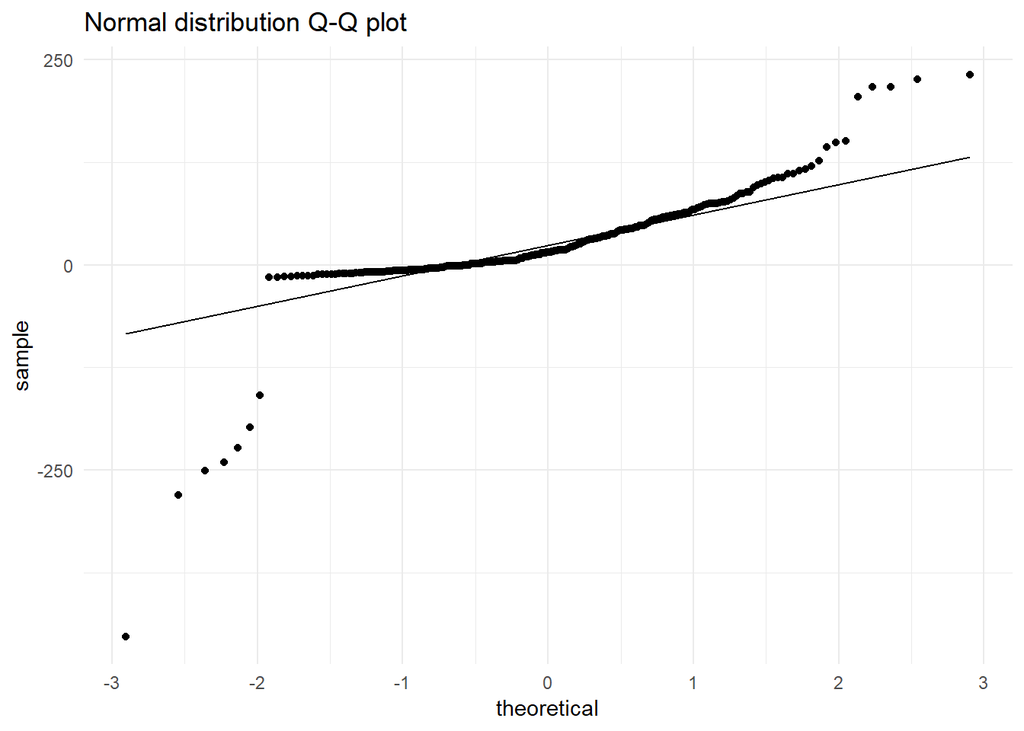

```r
ggplot(attendance,aes(sample = as.numeric(diff.out.time))) +
  stat_qq() + stat_qq_line() +
  ggtitle("Normal distribution Q-Q plot") +
  theme_minimal()
```

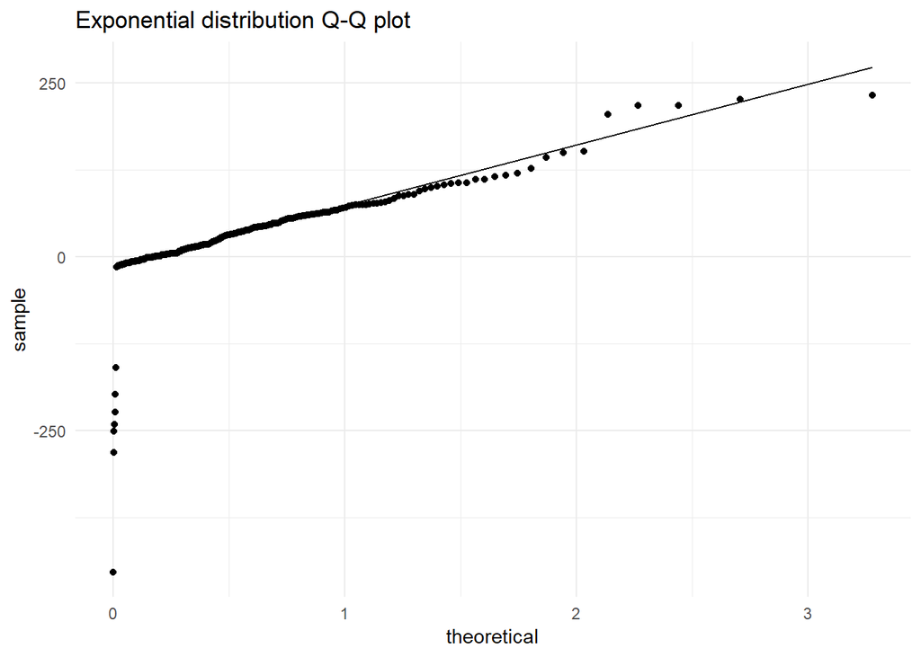

```r
params <- as.list(fitdistr(rexp(nrow(attendance), rate = 2), "exponential")$estimate)
ggplot(attendance,aes(sample = as.numeric(diff.out.time))) +
  stat_qq(distribution = qexp, dparams = params) +
  stat_qq_line(distribution = qexp, dparams = params) +
  ggtitle("Exponential distribution Q-Q plot") +
  theme_minimal()
```

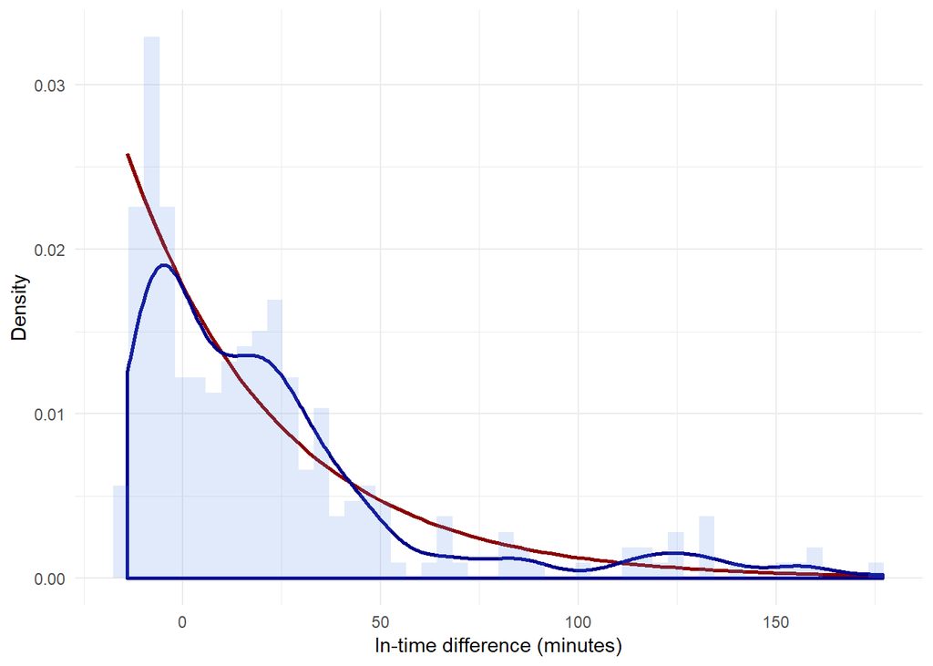

```r
lamda <- 1/mean(sd(as.numeric(attendance$diff.in.time)),mean(as.numeric(attendance$diff.in.time)))
exp.curve <- function(x){
                lamda*exp(-lamda*(x +15))
             }
ggplot(attendance,aes(x = as.numeric(diff.in.time))) +
  stat_function(fun = exp.curve, color="darkred",  size = 1) +
  geom_density(aes(y=..density..), color="darkblue",  size = 1)+
  geom_histogram(aes(y=..density..), bins = 50, fill = "cornflowerblue", alpha = 0.2) +
  labs(x = 'In-time difference (minutes)', y='Density') +
  theme_minimal()
```

Created on 29th Nov 2018, Achyuthuni Sri Harsha